# Web-based Positive Psychology Interventions

lmw & hn

31 Oktober 2018

# Web-based Positive Psychology Interventions: A Reexamination of Effectiveness

## Source

- Woodworth, R. J., O’Brien-Malone, A., Diamond, M. R. and Schüz, B. (2018). Data from, ‘Web-based Positive Psychology Interventions: A Reexamination of Effectiveness’. *Journal of Open Psychology Data*, *6*: 1. DOI: https://doi.org/10.5334/jopd.35
- See https://openpsychologydata.metajnl.com/articles/10.5334/jopd.35/ for details.
- The dataset is available from figshare at https://doi.org/10.6084/m9.figshare.1577563.v1.

## Study data

The study data is stored in 2 seperate files: `participant-info.csv` & `ahi-cesd.csv`

### File `participant-info.csv`

Contains *demographic information* on participants:

- `id`: participant id
- `intervention`: 3 positive psychology interventions, plus 1 control condition:
  - 1 = “Using Signature Strengths”,
  - 2 = “Three Good Things”,
  - 3 = “Gratitude Visit”,
  - 4 = “Recording early memories” (control condition).
- `sex`:
  - 1 = female,
  - 2 = male.
- `age`: participant’s age (in years).
- `educ`: level of education:
  - 1 = Less than Year 12,
  - 2 = Year 12,
  - 3 = Vocational training,
  - 4 = Bachelor’s degree,
  - 5 = Postgraduate degree.
- `income`:
  - 1 = below average,
  - 2 = average,
  - 3 = above average.

### File `ahi-cesd.csv`

Contains data of the 24 items of the *Authentic Happiness Inventory* (AHI) and to the 20 items of the *Center for Epidemiological Studies Depression* (CES-D) scale.

- `id`: Particpant ID
- `occasion`: Measurement occasion:
  - 0 = Pretest (i.e., at enrolment),
  - 1 = Posttest (i.e., 7 days after pretest),
  - 2 = 1-week follow-up, (i.e., 14 days after pretest, 7 days after posttest),
  - 3 = 1-month follow-up, (i.e., 38 days after pretest, 31 days after posttest),
  - 4 = 3-month follow-up, (i.e., 98 days after pretest, 91 days after posttest),
  - 5 = 6-month follow-up, (i.e., 189 days after pretest, 182 days after posttest).
- `elapsed.days`: time since enrolment measured in fractional days
- `intervention`: intervention group
- `ahi01`–`ahi24`: responses on 24 AHI items
- `cesd01`–`cesd20`: responses on 20 CES-D items
- `ahiTotal`: total AHI score
- `cesdTotal`: total CES-D score

### Step 1: Import data

```r
## Lisa:

ahi_cesd <- read_delim("~/Uni/7. Semester/HiWi/Data/Web-based positive psychology interventions/ahi-cesd.csv", ";", escape_double = FALSE, trim_ws = TRUE)

participant_info <- read_delim("~/Uni/7. Semester/HiWi/Data/Web-based positive psychology interventions/participant-info.csv", ";", escape_double = FALSE, trim_ws = TRUE)
```

```r
## Hans:

# library(data.table)

## Get & set current path:
# cur.path <- dirname(rstudioapi::getActiveDocumentContext()$path)
# cur.path
# setwd(cur.path) # set to current directory

my_path <- "/Users/hneth/Desktop/stuff/Dropbox/_code/R/_teachR/ds4psy/data/_posPsy"

ahi_cesd <- read_delim(paste0(my_path, "/ahi-cesd.csv"), ";",
                       escape_double = FALSE, trim_ws = TRUE)
participant_info <- read_delim(paste0(my_path, "/participant-info.csv"), ";",
                               escape_double = FALSE, trim_ws = TRUE)
## Save data files:
## save(participant_info, file = "./data/p_info.RData")
# write_csv(participant_info, path = "/Users/hneth/Desktop/stuff/Dropbox/_code/R/_teachR/ds4psy/data/posPsy_participants.csv")

## Restore data files:
# p_info <- read_csv(file = "/Users/hneth/Desktop/stuff/Dropbox/_code/R/_teachR/ds4psy/data/posPsy_participants.csv")
# p_info <- read_csv(file = "http://rpository.com/ds4psy/data/posPsy_participants.csv")
# p_info

# all.equal(participant_info, p_info)
```

### Step 2: Inspect data

```r
glimpse(participant_info)
```

```
## Observations: 295
## Variables: 6
## $ id           <int> 1, 2, 3, 4, 5, 6, 7, 8, 9, 10, 11, 12, 13, 14, 15...
## $ intervention <int> 4, 1, 4, 3, 2, 1, 3, 2, 1, 2, 2, 2, 4, 4, 4, 4, 3...
## $ sex          <int> 2, 1, 1, 1, 2, 1, 1, 1, 1, 1, 1, 1, 1, 1, 2, 1, 1...
## $ age          <int> 35, 59, 51, 50, 58, 31, 44, 57, 36, 45, 56, 46, 3...
## $ educ         <int> 5, 1, 4, 5, 5, 5, 5, 4, 4, 4, 5, 4, 5, 1, 2, 1, 4...
## $ income       <int> 3, 1, 3, 2, 2, 1, 2, 2, 3, 3, 1, 3, 3, 2, 2, 1, 2...
```

```r
glimpse(ahi_cesd)
```

```
## Observations: 992
## Variables: 50
## $ id           <int> 1, 1, 2, 2, 2, 2, 2, 2, 3, 3, 4, 4, 4, 4, 5, 5, 5...
## $ occasion     <int> 0, 1, 0, 1, 2, 3, 4, 5, 0, 2, 0, 1, 3, 4, 0, 1, 2...
## $ elapsed.days <chr> "0", "1.177.273.148", "0", "8.017.523.148", "1.43...
## $ intervention <int> 4, 4, 1, 1, 1, 1, 1, 1, 4, 4, 3, 3, 3, 3, 2, 2, 2...
## $ ahi01        <int> 2, 3, 3, 3, 3, 3, 3, 3, 3, 3, 2, 3, 1, 3, 1, 1, 2...
## $ ahi02        <int> 3, 3, 4, 4, 4, 4, 3, 3, 3, 3, 2, 2, 2, 2, 2, 2, 2...
## $ ahi03        <int> 2, 4, 3, 4, 4, 4, 2, 3, 2, 3, 3, 3, 2, 3, 3, 3, 3...
## $ ahi04        <int> 3, 3, 4, 4, 4, 4, 3, 4, 4, 4, 2, 4, 4, 4, 2, 2, 2...
## $ ahi05        <int> 3, 3, 2, 3, 3, 4, 3, 2, 2, 4, 2, 2, 2, 2, 2, 2, 2...
## $ ahi06        <int> 2, 4, 3, 3, 3, 4, 3, 3, 3, 4, 3, 3, 1, 1, 2, 2, 2...
## $ ahi07        <int> 3, 4, 4, 4, 4, 4, 3, 3, 4, 4, 3, 3, 2, 3, 1, 1, 2...
## $ ahi08        <int> 3, 3, 3, 4, 3, 3, 3, 4, 3, 3, 1, 1, 1, 2, 1, 2, 2...
## $ ahi09        <int> 3, 3, 3, 4, 4, 4, 4, 3, 4, 4, 5, 5, 4, 3, 2, 2, 2...
```

[output cut: 37 more lines]

```r
## How many occasions (lines) are there for each participant?
# ahi_cesd
occasions_pp <- ahi_cesd %>%
  group_by(id) %>%
  summarise(n = n())

knitr::kable(head(occasions_pp))
```

| id | n |
| --- | --- |
| 1 | 2 |
| 2 | 6 |
| 3 | 2 |
| 4 | 4 |
| 5 | 5 |
| 6 | 3 |

```r
## How many participants with all 6 occasions?

occasions_pp %>%
  filter(n == 6) %>%
  nrow()
```

```
## [1] 74
```

### Step 3: Combine data in one tibble

Note that `ahi_cesd` consists of several blocks of data (one per `occasion`, including all participants still participating in this occasion).

#### Step 3.1.: Split `ahi_cesd` into parts

Edit `ahi_cesd`: Filter each occasion into a separate data file and combine them afterwards:

Goal: 1 block for each `occasion`, 1 row per participant

```r
# Create individual tibbles for every observation
#  to later combine them using full_join()
ahi_cesd_0 <- ahi_cesd%>%
  group_by(id, occasion)%>%
  filter(occasion == 0)

ahi_cesd_1 <- ahi_cesd%>%
  group_by(id, occasion)%>%
  filter(occasion == 1)

ahi_cesd_2 <- ahi_cesd%>%
  group_by(id, occasion)%>%
  filter(occasion == 2)

ahi_cesd_3 <- ahi_cesd%>%
  group_by(id, occasion)%>%
  filter(occasion == 3)

ahi_cesd_4 <- ahi_cesd%>%
  group_by(id, occasion)%>%
  filter(occasion == 4)

ahi_cesd_5 <- ahi_cesd%>%
  group_by(id, occasion)%>%
  filter(occasion == 5)
```

Now we can join the 6 parts by participant `id`:

```r
# Join parts:
new1 <- full_join(ahi_cesd_0, ahi_cesd_1, by = "id", suffix = c(".0", ".1"))
new2 <- full_join(new1, ahi_cesd_2, by = "id", suffix = c(".1", ".2"))
new3 <- full_join(new2, ahi_cesd_3, by = "id", suffix = c(".2", ".3"))
new4 <- full_join(new3, ahi_cesd_4, by = "id", suffix = c(".3", "4"))

new_final <- full_join(new4, ahi_cesd_5, by = "id", suffix = c(".4", ".5"))

## check:
# new_final
```

#### Step 3.2: Combine data sets

Joining `participant_info` with `new_final`:

```r
complete_data <- full_join(participant_info, new_final, by = "id")

## Check:
# complete_data
dim(complete_data)
```

```
## [1] 297 300
```

#### Step 3.3: Remove redundancy

Delete redundant `intervention.*` columns, only retaining the column `intervention`:

```r
# complete_data <- select(complete_data, -intervention.0)
# complete_data <- select(complete_data, -intervention.1)
# complete_data <- select(complete_data, -intervention.2)
# complete_data <- select(complete_data, -intervention.3)
# complete_data <- select(complete_data, -intervention.4)
# complete_data <- select(complete_data, -intervention.5)
#
# dim(complete_data)

## Task:Is there an easier way to handle this?
## In 1 line:
complete_data <- select(complete_data, -intervention.0, -intervention.1, -intervention.2,
                                       -intervention.3, -intervention.4, -intervention.5)
dim(complete_data)
```

```
## [1] 297 294
```

### Step 4: Explore data sets

#### Only participant info data

```r
# number of participants:
participant_info %>%
  count()
```

```
## # A tibble: 1 x 1
##       n
##   <int>
## 1   295
```

```r
# number of participants per intervention group:
participant_info %>%
  group_by(intervention) %>%
  summarise(n = n(),
            mean_age_i = mean(age, na.rm = TRUE),
            min_age_i = min(age, na.rm = TRUE),
            max_age_i = max(age, na.rm = TRUE))
```

```
## # A tibble: 4 x 5
##   intervention     n mean_age_i min_age_i max_age_i
##          <int> <int>      <dbl>     <dbl>     <dbl>
## 1            1    72       44.6        22        71
## 2            2    76       45.4        18        83
## 3            3    74       43.3        19        71
## 4            4    73       41.7        19        75
```

```r
# number of male / female participants:
participant_info %>%
  group_by(sex) %>%
  summarise(n = n())
```

```
## # A tibble: 2 x 2
##     sex     n
##   <int> <int>
## 1     1   251
## 2     2    44
```

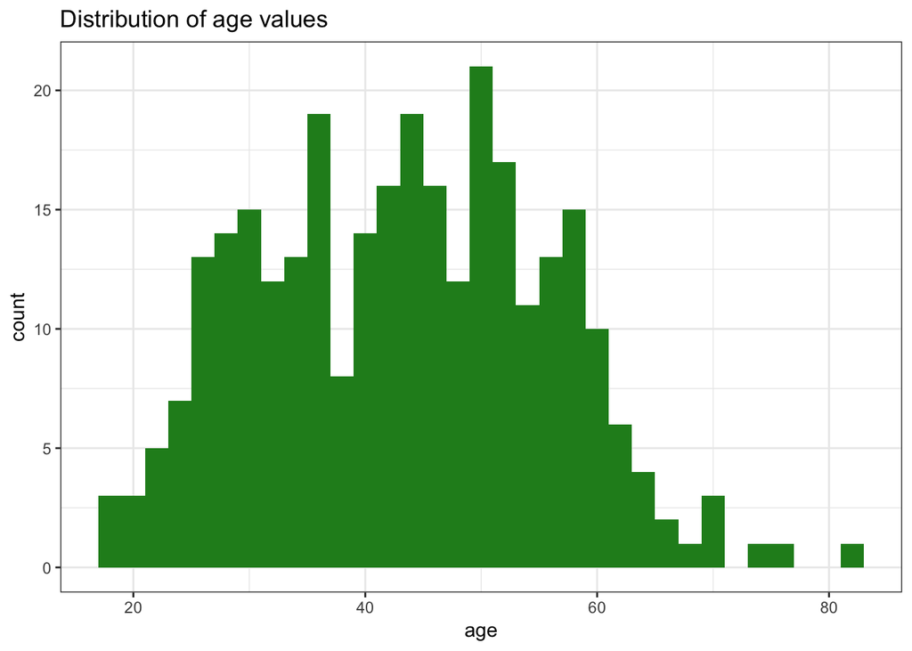

```r
# Age distribution:
ggplot(participant_info) +
  geom_histogram(mapping = aes(age), binwidth = 2, fill = "forestgreen") +
  theme_bw() +
  labs(title = "Distribution of age values")
```

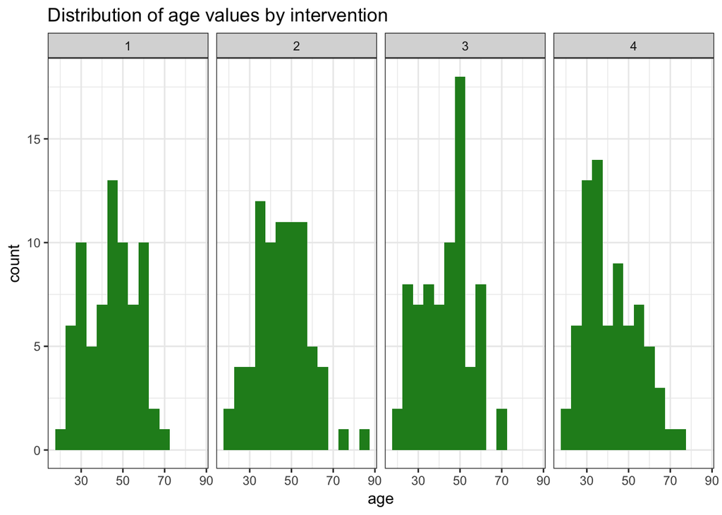

```r
# Age distribution by intervention:
ggplot(participant_info) +
  geom_histogram(mapping = aes(age), binwidth = 5, fill = "forestgreen") +
  theme_bw() +
  labs(title = "Distribution of age values by intervention") +
  facet_grid(.~intervention)
```

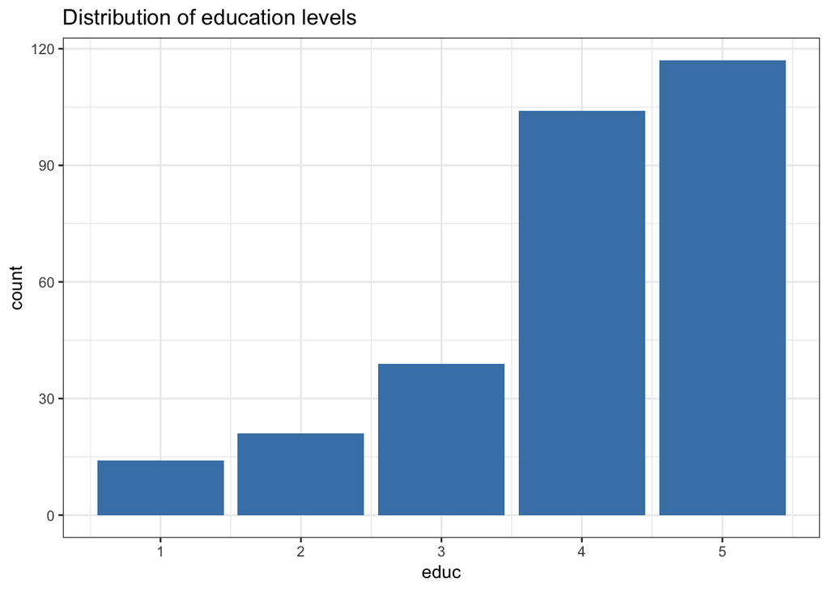

```r
# Distribution of education levels:
ggplot(participant_info) +
  geom_bar(mapping = aes(educ), fill = "steelblue") +
  labs(title = "Distribution of education levels") +
  theme_bw()
```

#### Explore `ahi_i` and `cesd_i` scores

```r
ahi_cesd %>%
  group_by(intervention) %>%
  summarize(mean_ahi_i = mean(ahiTotal, na.rm = TRUE),
            mean_cesd_i = mean(cesdTotal, na.rm = TRUE))
```

```
## # A tibble: 4 x 3
##   intervention mean_ahi_i mean_cesd_i
##          <int>      <dbl>       <dbl>
## 1            1       71.8        13.7
## 2            2       71.8        14.2
## 3            3       72.0        14.6
## 4            4       75.4        10.3
```

```r
# ggplot()
```

```r
# new variable improvement in ahiTotal/cesdTotal
complete_data %>%
  mutate(improve.ahi = ahiTotal.5 - ahiTotal.0)
```

```
## # A tibble: 297 x 295
##       id intervention   sex   age  educ income occasion.0 elapsed.days.0
##    <int>        <int> <int> <int> <int>  <int>      <int> <chr>
##  1     1            4     2    35     5      3          0 0
##  2     2            1     1    59     1      1          0 0
##  3     3            4     1    51     4      3          0 0
##  4     4            3     1    50     5      2          0 0
##  5     5            2     2    58     5      2          0 0
##  6     6            1     1    31     5      1          0 0
##  7     7            3     1    44     5      2          0 0
##  8     8            2     1    57     4      2          0 0
##  9     8            2     1    57     4      2          0 0
## 10     9            1     1    36     4      3          0 0
## # ... with 287 more rows, and 287 more variables: ahi01.0 <int>,
## #   ahi02.0 <int>, ahi03.0 <int>, ahi04.0 <int>, ahi05.0 <int>,
## #   ahi06.0 <int>, ahi07.0 <int>, ahi08.0 <int>, ahi09.0 <int>,
## #   ahi10.0 <int>, ahi11.0 <int>, ahi12.0 <int>, ahi13.0 <int>,
## #   ahi14.0 <int>, ahi15.0 <int>, ahi16.0 <int>, ahi17.0 <int>,
## #   ahi18.0 <int>, ahi19.0 <int>, ahi20.0 <int>, ahi21.0 <int>,
## #   ahi22.0 <int>, ahi23.0 <int>, ahi24.0 <int>, cesd01.0 <int>,
## #   cesd02.0 <int>, cesd03.0 <int>, cesd04.0 <int>, cesd05.0 <int>,
## #   cesd06.0 <int>, cesd07.0 <int>, cesd08.0 <int>, cesd09.0 <int>,
## #   cesd10.0 <int>, cesd11.0 <int>, cesd12.0 <int>, cesd13.0 <int>,
## #   cesd14.0 <int>, cesd15.0 <int>, cesd16.0 <int>, cesd17.0 <int>,
## #   cesd18.0 <int>, cesd19.0 <int>, cesd20.0 <int>, ahiTotal.0 <int>,
## #   cesdTotal.0 <int>, occasion.1 <int>, elapsed.days.1 <chr>,
## #   ahi01.1 <int>, ahi02.1 <int>, ahi03.1 <int>, ahi04.1 <int>,
## #   ahi05.1 <int>, ahi06.1 <int>, ahi07.1 <int>, ahi08.1 <int>,
## #   ahi09.1 <int>, ahi10.1 <int>, ahi11.1 <int>, ahi12.1 <int>,
## #   ahi13.1 <int>, ahi14.1 <int>, ahi15.1 <int>, ahi16.1 <int>,
## #   ahi17.1 <int>, ahi18.1 <int>, ahi19.1 <int>, ahi20.1 <int>,
## #   ahi21.1 <int>, ahi22.1 <int>, ahi23.1 <int>, ahi24.1 <int>,
## #   cesd01.1 <int>, cesd02.1 <int>, cesd03.1 <int>, cesd04.1 <int>,
## #   cesd05.1 <int>, cesd06.1 <int>, cesd07.1 <int>, cesd08.1 <int>,
## #   cesd09.1 <int>, cesd10.1 <int>, cesd11.1 <int>, cesd12.1 <int>,
## #   cesd13.1 <int>, cesd14.1 <int>, cesd15.1 <int>, cesd16.1 <int>,
## #   cesd17.1 <int>, cesd18.1 <int>, cesd19.1 <int>, cesd20.1 <int>,
## #   ahiTotal.1 <int>, cesdTotal.1 <int>, occasion.2 <int>,
## #   elapsed.days.2 <chr>, ahi01.2 <int>, ahi02.2 <int>, ahi03.2 <int>,
## #   ahi04.2 <int>, …
```

```r
complete_data%>%
  mutate(improve.cesd = cesdTotal.5 - cesdTotal.0)
```

```
## # A tibble: 297 x 295
##       id intervention   sex   age  educ income occasion.0 elapsed.days.0
##    <int>        <int> <int> <int> <int>  <int>      <int> <chr>
##  1     1            4     2    35     5      3          0 0
##  2     2            1     1    59     1      1          0 0
##  3     3            4     1    51     4      3          0 0
##  4     4            3     1    50     5      2          0 0
##  5     5            2     2    58     5      2          0 0
##  6     6            1     1    31     5      1          0 0
##  7     7            3     1    44     5      2          0 0
##  8     8            2     1    57     4      2          0 0
##  9     8            2     1    57     4      2          0 0
## 10     9            1     1    36     4      3          0 0
## # ... with 287 more rows, and 287 more variables: ahi01.0 <int>,
## #   ahi02.0 <int>, ahi03.0 <int>, ahi04.0 <int>, ahi05.0 <int>,
## #   ahi06.0 <int>, ahi07.0 <int>, ahi08.0 <int>, ahi09.0 <int>,
## #   ahi10.0 <int>, ahi11.0 <int>, ahi12.0 <int>, ahi13.0 <int>,
## #   ahi14.0 <int>, ahi15.0 <int>, ahi16.0 <int>, ahi17.0 <int>,
## #   ahi18.0 <int>, ahi19.0 <int>, ahi20.0 <int>, ahi21.0 <int>,
## #   ahi22.0 <int>, ahi23.0 <int>, ahi24.0 <int>, cesd01.0 <int>,
## #   cesd02.0 <int>, cesd03.0 <int>, cesd04.0 <int>, cesd05.0 <int>,
## #   cesd06.0 <int>, cesd07.0 <int>, cesd08.0 <int>, cesd09.0 <int>,
## #   cesd10.0 <int>, cesd11.0 <int>, cesd12.0 <int>, cesd13.0 <int>,
## #   cesd14.0 <int>, cesd15.0 <int>, cesd16.0 <int>, cesd17.0 <int>,
## #   cesd18.0 <int>, cesd19.0 <int>, cesd20.0 <int>, ahiTotal.0 <int>,
## #   cesdTotal.0 <int>, occasion.1 <int>, elapsed.days.1 <chr>,
## #   ahi01.1 <int>, ahi02.1 <int>, ahi03.1 <int>, ahi04.1 <int>,
## #   ahi05.1 <int>, ahi06.1 <int>, ahi07.1 <int>, ahi08.1 <int>,
## #   ahi09.1 <int>, ahi10.1 <int>, ahi11.1 <int>, ahi12.1 <int>,
## #   ahi13.1 <int>, ahi14.1 <int>, ahi15.1 <int>, ahi16.1 <int>,
## #   ahi17.1 <int>, ahi18.1 <int>, ahi19.1 <int>, ahi20.1 <int>,
## #   ahi21.1 <int>, ahi22.1 <int>, ahi23.1 <int>, ahi24.1 <int>,
## #   cesd01.1 <int>, cesd02.1 <int>, cesd03.1 <int>, cesd04.1 <int>,
## #   cesd05.1 <int>, cesd06.1 <int>, cesd07.1 <int>, cesd08.1 <int>,
## #   cesd09.1 <int>, cesd10.1 <int>, cesd11.1 <int>, cesd12.1 <int>,
## #   cesd13.1 <int>, cesd14.1 <int>, cesd15.1 <int>, cesd16.1 <int>,
## #   cesd17.1 <int>, cesd18.1 <int>, cesd19.1 <int>, cesd20.1 <int>,
## #   ahiTotal.1 <int>, cesdTotal.1 <int>, occasion.2 <int>,
## #   elapsed.days.2 <chr>, ahi01.2 <int>, ahi02.2 <int>, ahi03.2 <int>,
## #   ahi04.2 <int>, …
```

```r
# add to existing data
complete_data <- complete_data%>%
  mutate(improve.ahi = ahiTotal.5 - ahiTotal.0)


complete_data <- complete_data%>%
  mutate(improve.cesd = cesdTotal.5 - cesdTotal.0)


# mean improvement (overall)
complete_data %>%
  summarize(mean_improve_cesd = mean(improve.cesd, na.rm = TRUE),
            mean_improve_ahi = mean(improve.ahi, na.rm = TRUE))
```

```
## # A tibble: 1 x 2
##   mean_improve_cesd mean_improve_ahi
##               <dbl>            <dbl>
## 1             -2.25             5.24
```

```r
# mean improvement (per intervention)
## Which intervention group did improve most in ahi and cesd total scores?
complete_data %>%
  group_by(intervention) %>%
  summarize(mean_improve_cesd = mean(improve.cesd, na.rm = TRUE),
            mean_improve_ahi = mean(improve.ahi, na.rm = TRUE))
```

```
## # A tibble: 4 x 3
##   intervention mean_improve_cesd mean_improve_ahi
##          <int>             <dbl>            <dbl>
## 1            1            -2.18              7.07
## 2            2            -0.486             4.27
## 3            3            -4.30              4.09
## 4            4            -2.85              5.58
```